# Risk Factor Analysis

## Outcome Variable

**Outcome Variable:** stunted

## Predictor Variables

**Intervention Variable:** impfloor

**Adjustment Set:**

unadjusted

## Stratifying Variables

The analysis was stratified on these variable(s):

- agecat
- studyid
- country

## Data Summary

| agecat | studyid | country | impfloor | stunted | n_cell | n |
| --- | --- | --- | --- | --- | --- | --- |
| Birth | ki0047075b-MAL-ED | BANGLADESH | 0 | 0 | 16 | 234 |
| Birth | ki0047075b-MAL-ED | BANGLADESH | 0 | 1 | 2 | 234 |
| Birth | ki0047075b-MAL-ED | BANGLADESH | 1 | 0 | 180 | 234 |
| Birth | ki0047075b-MAL-ED | BANGLADESH | 1 | 1 | 36 | 234 |
| 6 months | ki0047075b-MAL-ED | BANGLADESH | 0 | 0 | 17 | 240 |
| 6 months | ki0047075b-MAL-ED | BANGLADESH | 0 | 1 | 2 | 240 |
| 6 months | ki0047075b-MAL-ED | BANGLADESH | 1 | 0 | 178 | 240 |
| 6 months | ki0047075b-MAL-ED | BANGLADESH | 1 | 1 | 43 | 240 |
| 24 months | ki0047075b-MAL-ED | BANGLADESH | 0 | 0 | 8 | 212 |
| 24 months | ki0047075b-MAL-ED | BANGLADESH | 0 | 1 | 9 | 212 |
| 24 months | ki0047075b-MAL-ED | BANGLADESH | 1 | 0 | 106 | 212 |
| 24 months | ki0047075b-MAL-ED | BANGLADESH | 1 | 1 | 89 | 212 |
| Birth | ki0047075b-MAL-ED | BRAZIL | 0 | 0 | 2 | 174 |
| Birth | ki0047075b-MAL-ED | BRAZIL | 0 | 1 | 0 | 174 |
| Birth | ki0047075b-MAL-ED | BRAZIL | 1 | 0 | 155 | 174 |
| Birth | ki0047075b-MAL-ED | BRAZIL | 1 | 1 | 17 | 174 |
| 6 months | ki0047075b-MAL-ED | BRAZIL | 0 | 0 | 2 | 209 |
| 6 months | ki0047075b-MAL-ED | BRAZIL | 0 | 1 | 0 | 209 |
| 6 months | ki0047075b-MAL-ED | BRAZIL | 1 | 0 | 201 | 209 |
| 6 months | ki0047075b-MAL-ED | BRAZIL | 1 | 1 | 6 | 209 |
| 24 months | ki0047075b-MAL-ED | BRAZIL | 0 | 0 | 2 | 169 |
| 24 months | ki0047075b-MAL-ED | BRAZIL | 0 | 1 | 0 | 169 |
| 24 months | ki0047075b-MAL-ED | BRAZIL | 1 | 0 | 161 | 169 |
| 24 months | ki0047075b-MAL-ED | BRAZIL | 1 | 1 | 6 | 169 |
| Birth | ki0047075b-MAL-ED | INDIA | 0 | 0 | 9 | 191 |
| Birth | ki0047075b-MAL-ED | INDIA | 0 | 1 | 1 | 191 |
| Birth | ki0047075b-MAL-ED | INDIA | 1 | 0 | 152 | 191 |
| Birth | ki0047075b-MAL-ED | INDIA | 1 | 1 | 29 | 191 |
| 6 months | ki0047075b-MAL-ED | INDIA | 0 | 0 | 11 | 235 |
| 6 months | ki0047075b-MAL-ED | INDIA | 0 | 1 | 4 | 235 |

[output cut: 139 more lines]

The following strata were considered:

- agecat: 24 months, studyid: ki0047075b-MAL-ED, country: BANGLADESH
- agecat: 24 months, studyid: ki0047075b-MAL-ED, country: BRAZIL
- agecat: 24 months, studyid: ki0047075b-MAL-ED, country: INDIA
- agecat: 24 months, studyid: ki0047075b-MAL-ED, country: NEPAL
- agecat: 24 months, studyid: ki0047075b-MAL-ED, country: PERU
- agecat: 24 months, studyid: ki0047075b-MAL-ED, country: SOUTH AFRICA
- agecat: 24 months, studyid: ki0047075b-MAL-ED, country: TANZANIA, UNITED REPUBLIC OF
- agecat: 24 months, studyid: ki1000108-CMC-V-BCS-2002, country: INDIA
- agecat: 24 months, studyid: ki1000108-IRC, country: INDIA
- agecat: 24 months, studyid: ki1017093-NIH-Birth, country: BANGLADESH
- agecat: 24 months, studyid: ki1017093b-PROVIDE, country: BANGLADESH
- agecat: 24 months, studyid: ki1017093c-NIH-Crypto, country: BANGLADESH
- agecat: 24 months, studyid: ki1113344-GMS-Nepal, country: NEPAL
- agecat: 24 months, studyid: ki1114097-CONTENT, country: PERU
- agecat: 24 months, studyid: kiGH5241-JiVitA-3, country: BANGLADESH
- agecat: 24 months, studyid: kiGH5241-JiVitA-4, country: BANGLADESH
- agecat: 6 months, studyid: ki0047075b-MAL-ED, country: BANGLADESH
- agecat: 6 months, studyid: ki0047075b-MAL-ED, country: BRAZIL
- agecat: 6 months, studyid: ki0047075b-MAL-ED, country: INDIA
- agecat: 6 months, studyid: ki0047075b-MAL-ED, country: NEPAL
- agecat: 6 months, studyid: ki0047075b-MAL-ED, country: PERU
- agecat: 6 months, studyid: ki0047075b-MAL-ED, country: SOUTH AFRICA
- agecat: 6 months, studyid: ki0047075b-MAL-ED, country: TANZANIA, UNITED REPUBLIC OF
- agecat: 6 months, studyid: ki1000108-CMC-V-BCS-2002, country: INDIA
- agecat: 6 months, studyid: ki1000108-IRC, country: INDIA
- agecat: 6 months, studyid: ki1017093-NIH-Birth, country: BANGLADESH
- agecat: 6 months, studyid: ki1017093b-PROVIDE, country: BANGLADESH
- agecat: 6 months, studyid: ki1017093c-NIH-Crypto, country: BANGLADESH
- agecat: 6 months, studyid: ki1113344-GMS-Nepal, country: NEPAL
- agecat: 6 months, studyid: ki1114097-CONTENT, country: PERU
- agecat: 6 months, studyid: kiGH5241-JiVitA-3, country: BANGLADESH
- agecat: 6 months, studyid: kiGH5241-JiVitA-4, country: BANGLADESH
- agecat: Birth, studyid: ki0047075b-MAL-ED, country: BANGLADESH
- agecat: Birth, studyid: ki0047075b-MAL-ED, country: BRAZIL
- agecat: Birth, studyid: ki0047075b-MAL-ED, country: INDIA
- agecat: Birth, studyid: ki0047075b-MAL-ED, country: NEPAL
- agecat: Birth, studyid: ki0047075b-MAL-ED, country: PERU
- agecat: Birth, studyid: ki0047075b-MAL-ED, country: SOUTH AFRICA
- agecat: Birth, studyid: ki0047075b-MAL-ED, country: TANZANIA, UNITED REPUBLIC OF
- agecat: Birth, studyid: ki1000108-CMC-V-BCS-2002, country: INDIA
- agecat: Birth, studyid: ki1000108-IRC, country: INDIA
- agecat: Birth, studyid: ki1017093-NIH-Birth, country: BANGLADESH
- agecat: Birth, studyid: ki1017093c-NIH-Crypto, country: BANGLADESH
- agecat: Birth, studyid: ki1114097-CONTENT, country: PERU
- agecat: Birth, studyid: kiGH5241-JiVitA-3, country: BANGLADESH
- agecat: Birth, studyid: kiGH5241-JiVitA-4, country: BANGLADESH

### Dropped Strata

Some strata were dropped due to rare outcomes:

- agecat: Birth, studyid: ki0047075b-MAL-ED, country: BANGLADESH
- agecat: 6 months, studyid: ki0047075b-MAL-ED, country: BANGLADESH
- agecat: Birth, studyid: ki0047075b-MAL-ED, country: BRAZIL
- agecat: 6 months, studyid: ki0047075b-MAL-ED, country: BRAZIL
- agecat: 24 months, studyid: ki0047075b-MAL-ED, country: BRAZIL
- agecat: Birth, studyid: ki0047075b-MAL-ED, country: INDIA
- agecat: 6 months, studyid: ki0047075b-MAL-ED, country: INDIA
- agecat: Birth, studyid: ki0047075b-MAL-ED, country: SOUTH AFRICA
- agecat: 6 months, studyid: ki0047075b-MAL-ED, country: SOUTH AFRICA
- agecat: Birth, studyid: ki0047075b-MAL-ED, country: TANZANIA, UNITED REPUBLIC OF
- agecat: 6 months, studyid: ki0047075b-MAL-ED, country: TANZANIA, UNITED REPUBLIC OF
- agecat: 24 months, studyid: ki0047075b-MAL-ED, country: TANZANIA, UNITED REPUBLIC OF
- agecat: Birth, studyid: ki1017093-NIH-Birth, country: BANGLADESH
- agecat: Birth, studyid: ki1017093c-NIH-Crypto, country: BANGLADESH
- agecat: 6 months, studyid: ki1114097-CONTENT, country: PERU
- agecat: 24 months, studyid: ki1114097-CONTENT, country: PERU
- agecat: Birth, studyid: ki1114097-CONTENT, country: PERU

## Methods Detail

We’re interested in the causal parameters $E[Y_a]$ for all values of $a \in \mathcal{A}$. These parameters represent the mean outcome if, possibly contrary to fact, we intervened to set all units to have $A=a$. Under the randomization and positivity assumptions, these are identified by the statistical parameters $\psi_a=E_W[E_{Y|A,W}(Y|A=a,W)]$. In addition, we’re interested in the mean of $Y$, $E[Y]$ under no intervention (the observed mean). We will estimate these parameters by using SuperLearner to fit the relevant likelihood factors – $E_{Y|A,W}(Y|A=a,W)$ and $p(A=a|W)$, and then updating our likelihood fit using a joint TMLE.

For unadjusted analyses ($W=\{\}$), initial likelihoods were estimated using Lrnr_glm to estimate the simple $E(Y|A)$ and Lrnr_mean to estimate $p(A)$. For adjusted analyses, a small library containing Lrnr_glmnet, Lrnr_xgboost, and Lrnr_mean was used.

Having estimated these parameters, we will then use the delta method to estimate relative risks and attributable risks relative to a prespecified baseline level of $A$.

```
##         stunted
## impfloor   0   1
##        0   0   0
##        1  80 180
##         stunted
## impfloor   0   1
##        0   0   0
##        1 190 115
##         stunted
## impfloor   0   1
##        0   0   0
##        1 170  87
##         stunted
## impfloor   0   1
##        0   0   0
##        1 235  68
##         stunted
## impfloor  0  1
##        0  0  0
##        1 58 13
##         stunted
## impfloor   0   1
##        0   0   0
##        1 255  32
```

# Results Detail

## Results Plots

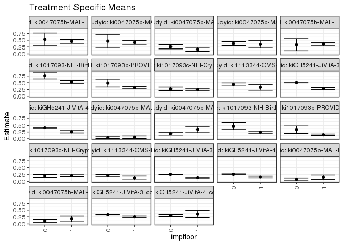

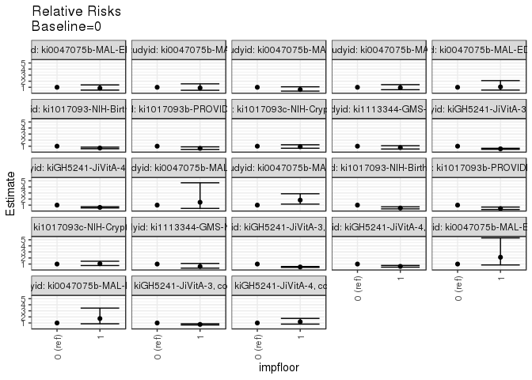

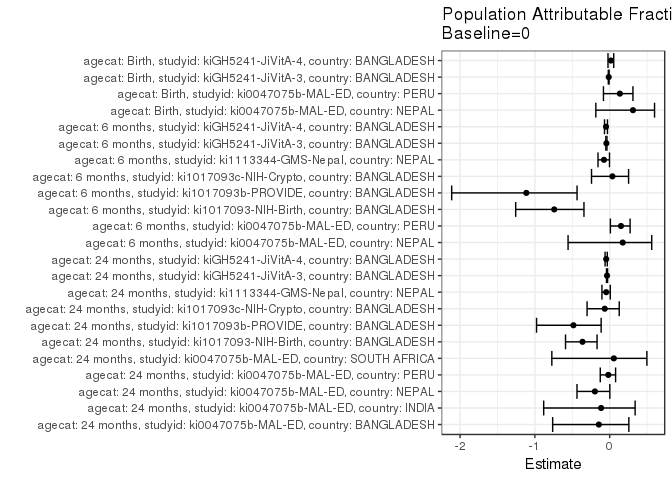

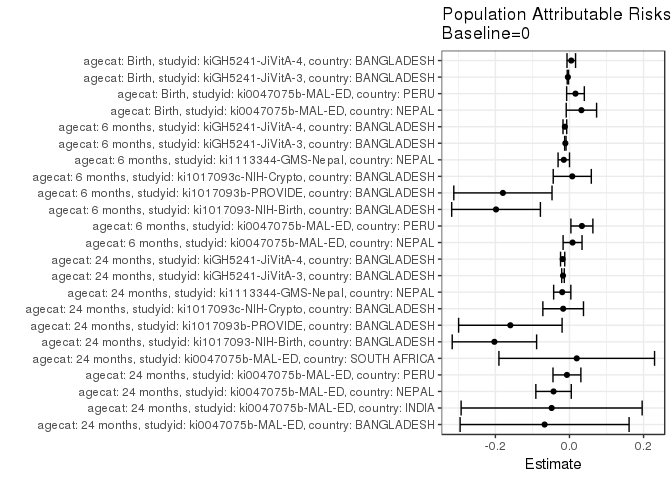

## Results Table

### Parameter: TSM

| agecat | studyid | country | intervention_level | baseline_level | estimate | ci_lower | ci_upper |
| --- | --- | --- | --- | --- | --- | --- | --- |
| Birth | ki0047075b-MAL-ED | NEPAL | 0 | NA | 0.0714286 | 0.0202831 | 0.1225740 |
| Birth | ki0047075b-MAL-ED | NEPAL | 1 | NA | 0.1515152 | 0.0647482 | 0.2382821 |
| Birth | ki0047075b-MAL-ED | PERU | 0 | NA | 0.1034483 | 0.0614734 | 0.1454232 |
| Birth | ki0047075b-MAL-ED | PERU | 1 | NA | 0.1785714 | 0.0780670 | 0.2790758 |
| Birth | kiGH5241-JiVitA-3 | BANGLADESH | 0 | NA | 0.3276897 | 0.3198221 | 0.3355574 |
| Birth | kiGH5241-JiVitA-3 | BANGLADESH | 1 | NA | 0.2490706 | 0.2175285 | 0.2806128 |
| Birth | kiGH5241-JiVitA-4 | BANGLADESH | 0 | NA | 0.2956059 | 0.2588175 | 0.3323942 |
| Birth | kiGH5241-JiVitA-4 | BANGLADESH | 1 | NA | 0.3521127 | 0.2233760 | 0.4808494 |
| 6 months | ki0047075b-MAL-ED | NEPAL | 0 | NA | 0.0396825 | 0.0055223 | 0.0738427 |
| 6 months | ki0047075b-MAL-ED | NEPAL | 1 | NA | 0.0582524 | 0.0129205 | 0.1035843 |
| 6 months | ki0047075b-MAL-ED | PERU | 0 | NA | 0.1886792 | 0.1359144 | 0.2414440 |
| 6 months | ki0047075b-MAL-ED | PERU | 1 | NA | 0.3448276 | 0.2222761 | 0.4673791 |
| 6 months | ki1017093-NIH-Birth | BANGLADESH | 0 | NA | 0.4655172 | 0.3370255 | 0.5940089 |
| 6 months | ki1017093-NIH-Birth | BANGLADESH | 1 | NA | 0.2431866 | 0.2046512 | 0.2817219 |
| 6 months | ki1017093b-PROVIDE | BANGLADESH | 0 | NA | 0.3409091 | 0.2007290 | 0.4810892 |
| 6 months | ki1017093b-PROVIDE | BANGLADESH | 1 | NA | 0.1465677 | 0.1166843 | 0.1764511 |
| 6 months | ki1017093c-NIH-Crypto | BANGLADESH | 0 | NA | 0.2022472 | 0.1431975 | 0.2612969 |
| 6 months | ki1017093c-NIH-Crypto | BANGLADESH | 1 | NA | 0.2122905 | 0.1776796 | 0.2469014 |
| 6 months | ki1113344-GMS-Nepal | NEPAL | 0 | NA | 0.2148760 | 0.1725750 | 0.2571771 |
| 6 months | ki1113344-GMS-Nepal | NEPAL | 1 | NA | 0.1282051 | 0.0539283 | 0.2024820 |
| 6 months | kiGH5241-JiVitA-3 | BANGLADESH | 0 | NA | 0.2625425 | 0.2541433 | 0.2709416 |
| 6 months | kiGH5241-JiVitA-3 | BANGLADESH | 1 | NA | 0.1351536 | 0.1169667 | 0.1533405 |
| 6 months | kiGH5241-JiVitA-4 | BANGLADESH | 0 | NA | 0.2647615 | 0.2497302 | 0.2797927 |
| 6 months | kiGH5241-JiVitA-4 | BANGLADESH | 1 | NA | 0.1627119 | 0.1268367 | 0.1985870 |
| 24 months | ki0047075b-MAL-ED | BANGLADESH | 0 | NA | 0.5294118 | 0.2915812 | 0.7672423 |
| 24 months | ki0047075b-MAL-ED | BANGLADESH | 1 | NA | 0.4564103 | 0.3863340 | 0.5264865 |
| 24 months | ki0047075b-MAL-ED | INDIA | 0 | NA | 0.4666667 | 0.2136414 | 0.7196920 |
| 24 months | ki0047075b-MAL-ED | INDIA | 1 | NA | 0.4150943 | 0.3486198 | 0.4815689 |
| 24 months | ki0047075b-MAL-ED | NEPAL | 0 | NA | 0.2601626 | 0.1824537 | 0.3378715 |
| 24 months | ki0047075b-MAL-ED | NEPAL | 1 | NA | 0.1632653 | 0.0899220 | 0.2366086 |
| 24 months | ki0047075b-MAL-ED | PERU | 0 | NA | 0.3750000 | 0.2978448 | 0.4521552 |
| 24 months | ki0047075b-MAL-ED | PERU | 1 | NA | 0.3469388 | 0.2133295 | 0.4805480 |
| 24 months | ki0047075b-MAL-ED | SOUTH AFRICA | 0 | NA | 0.3333333 | 0.1151006 | 0.5515661 |
| 24 months | ki0047075b-MAL-ED | SOUTH AFRICA | 1 | NA | 0.3545455 | 0.2911994 | 0.4178915 |
| 24 months | ki1017093-NIH-Birth | BANGLADESH | 0 | NA | 0.7600000 | 0.6414819 | 0.8785181 |
| 24 months | ki1017093-NIH-Birth | BANGLADESH | 1 | NA | 0.5305040 | 0.4800673 | 0.5809407 |
| 24 months | ki1017093b-PROVIDE | BANGLADESH | 0 | NA | 0.4888889 | 0.3427111 | 0.6350666 |
| 24 months | ki1017093b-PROVIDE | BANGLADESH | 1 | NA | 0.3157895 | 0.2762562 | 0.3553227 |
| 24 months | ki1017093c-NIH-Crypto | BANGLADESH | 0 | NA | 0.2738095 | 0.2063154 | 0.3413036 |
| 24 months | ki1017093c-NIH-Crypto | BANGLADESH | 1 | NA | 0.2485549 | 0.2029730 | 0.2941368 |
| 24 months | ki1113344-GMS-Nepal | NEPAL | 0 | NA | 0.4376997 | 0.3826680 | 0.4927314 |
| 24 months | ki1113344-GMS-Nepal | NEPAL | 1 | NA | 0.3333333 | 0.2243048 | 0.4423619 |
| 24 months | kiGH5241-JiVitA-3 | BANGLADESH | 0 | NA | 0.5081285 | 0.4948788 | 0.5213782 |
| 24 months | kiGH5241-JiVitA-3 | BANGLADESH | 1 | NA | 0.2848665 | 0.2425763 | 0.3271567 |
| 24 months | kiGH5241-JiVitA-4 | BANGLADESH | 0 | NA | 0.4107656 | 0.3930784 | 0.4284527 |
| 24 months | kiGH5241-JiVitA-4 | BANGLADESH | 1 | NA | 0.2561837 | 0.2142402 | 0.2981273 |

### Parameter: E(Y)

| agecat | studyid | country | intervention_level | baseline_level | estimate | ci_lower | ci_upper |
| --- | --- | --- | --- | --- | --- | --- | --- |
| Birth | ki0047075b-MAL-ED | NEPAL | NA | NA | 0.1036585 | 0.0568642 | 0.1504529 |
| Birth | ki0047075b-MAL-ED | PERU | NA | NA | 0.1196911 | 0.0800828 | 0.1592995 |
| Birth | kiGH5241-JiVitA-3 | BANGLADESH | NA | NA | 0.3233655 | 0.3156750 | 0.3310561 |
| Birth | kiGH5241-JiVitA-4 | BANGLADESH | NA | NA | 0.3004866 | 0.2649179 | 0.3360553 |
| 6 months | ki0047075b-MAL-ED | NEPAL | NA | NA | 0.0480349 | 0.0202781 | 0.0757918 |
| 6 months | ki0047075b-MAL-ED | PERU | NA | NA | 0.2222222 | 0.1725409 | 0.2719036 |
| 6 months | ki1017093-NIH-Birth | BANGLADESH | NA | NA | 0.2672897 | 0.2297549 | 0.3048246 |
| 6 months | ki1017093b-PROVIDE | BANGLADESH | NA | NA | 0.1612350 | 0.1313580 | 0.1911120 |
| 6 months | ki1017093c-NIH-Crypto | BANGLADESH | NA | NA | 0.2097902 | 0.1799252 | 0.2396552 |
| 6 months | ki1113344-GMS-Nepal | NEPAL | NA | NA | 0.1995465 | 0.1622033 | 0.2368897 |
| 6 months | kiGH5241-JiVitA-3 | BANGLADESH | NA | NA | 0.2514160 | 0.2432636 | 0.2595684 |
| 6 months | kiGH5241-JiVitA-4 | BANGLADESH | NA | NA | 0.2522803 | 0.2382170 | 0.2663435 |
| 24 months | ki0047075b-MAL-ED | BANGLADESH | NA | NA | 0.4622642 | 0.3949918 | 0.5295365 |
| 24 months | ki0047075b-MAL-ED | INDIA | NA | NA | 0.4185022 | 0.3541865 | 0.4828179 |
| 24 months | ki0047075b-MAL-ED | NEPAL | NA | NA | 0.2171946 | 0.1627082 | 0.2716810 |
| 24 months | ki0047075b-MAL-ED | PERU | NA | NA | 0.3681592 | 0.3013164 | 0.4350020 |
| 24 months | ki0047075b-MAL-ED | SOUTH AFRICA | NA | NA | 0.3529412 | 0.2921001 | 0.4137823 |
| 24 months | ki1017093-NIH-Birth | BANGLADESH | NA | NA | 0.5573770 | 0.5102104 | 0.6045437 |
| 24 months | ki1017093b-PROVIDE | BANGLADESH | NA | NA | 0.3292894 | 0.2909105 | 0.3676684 |
| 24 months | ki1017093c-NIH-Crypto | BANGLADESH | NA | NA | 0.2568093 | 0.2190047 | 0.2946140 |
| 24 months | ki1113344-GMS-Nepal | NEPAL | NA | NA | 0.4181818 | 0.3688464 | 0.4675172 |
| 24 months | kiGH5241-JiVitA-3 | BANGLADESH | NA | NA | 0.4906493 | 0.4775353 | 0.5037634 |
| 24 months | kiGH5241-JiVitA-4 | BANGLADESH | NA | NA | 0.3923304 | 0.3753233 | 0.4093375 |

### Parameter: RR

| agecat | studyid | country | intervention_level | baseline_level | estimate | ci_lower | ci_upper |
| --- | --- | --- | --- | --- | --- | --- | --- |
| Birth | ki0047075b-MAL-ED | NEPAL | 0 | 0 | 1.0000000 | 1.0000000 | 1.0000000 |
| Birth | ki0047075b-MAL-ED | NEPAL | 1 | 0 | 2.1212121 | 0.8479942 | 5.3060989 |
| Birth | ki0047075b-MAL-ED | PERU | 0 | 0 | 1.0000000 | 1.0000000 | 1.0000000 |
| Birth | ki0047075b-MAL-ED | PERU | 1 | 0 | 1.7261905 | 0.8624997 | 3.4547645 |
| Birth | kiGH5241-JiVitA-3 | BANGLADESH | 0 | 0 | 1.0000000 | 1.0000000 | 1.0000000 |
| Birth | kiGH5241-JiVitA-3 | BANGLADESH | 1 | 0 | 0.7600807 | 0.6684550 | 0.8642656 |
| Birth | kiGH5241-JiVitA-4 | BANGLADESH | 0 | 0 | 1.0000000 | 1.0000000 | 1.0000000 |
| Birth | kiGH5241-JiVitA-4 | BANGLADESH | 1 | 0 | 1.1911559 | 0.8104552 | 1.7506860 |
| 6 months | ki0047075b-MAL-ED | NEPAL | 0 | 0 | 1.0000000 | 1.0000000 | 1.0000000 |
| 6 months | ki0047075b-MAL-ED | NEPAL | 1 | 0 | 1.4679612 | 0.4599809 | 4.6847810 |
| 6 months | ki0047075b-MAL-ED | PERU | 0 | 0 | 1.0000000 | 1.0000000 | 1.0000000 |
| 6 months | ki0047075b-MAL-ED | PERU | 1 | 0 | 1.8275862 | 1.1627211 | 2.8726333 |
| 6 months | ki1017093-NIH-Birth | BANGLADESH | 0 | 0 | 1.0000000 | 1.0000000 | 1.0000000 |
| 6 months | ki1017093-NIH-Birth | BANGLADESH | 1 | 0 | 0.5224008 | 0.3799974 | 0.7181696 |
| 6 months | ki1017093b-PROVIDE | BANGLADESH | 0 | 0 | 1.0000000 | 1.0000000 | 1.0000000 |
| 6 months | ki1017093b-PROVIDE | BANGLADESH | 1 | 0 | 0.4299320 | 0.2716892 | 0.6803417 |
| 6 months | ki1017093c-NIH-Crypto | BANGLADESH | 0 | 0 | 1.0000000 | 1.0000000 | 1.0000000 |
| 6 months | ki1017093c-NIH-Crypto | BANGLADESH | 1 | 0 | 1.0496586 | 0.7513087 | 1.4664854 |
| 6 months | ki1113344-GMS-Nepal | NEPAL | 0 | 0 | 1.0000000 | 1.0000000 | 1.0000000 |
| 6 months | ki1113344-GMS-Nepal | NEPAL | 1 | 0 | 0.5966469 | 0.3235757 | 1.1001678 |
| 6 months | kiGH5241-JiVitA-3 | BANGLADESH | 0 | 0 | 1.0000000 | 1.0000000 | 1.0000000 |
| 6 months | kiGH5241-JiVitA-3 | BANGLADESH | 1 | 0 | 0.5147875 | 0.4496533 | 0.5893568 |
| 6 months | kiGH5241-JiVitA-4 | BANGLADESH | 0 | 0 | 1.0000000 | 1.0000000 | 1.0000000 |
| 6 months | kiGH5241-JiVitA-4 | BANGLADESH | 1 | 0 | 0.6145602 | 0.4899760 | 0.7708220 |
| 24 months | ki0047075b-MAL-ED | BANGLADESH | 0 | 0 | 1.0000000 | 1.0000000 | 1.0000000 |
| 24 months | ki0047075b-MAL-ED | BANGLADESH | 1 | 0 | 0.8621083 | 0.5362669 | 1.3859341 |
| 24 months | ki0047075b-MAL-ED | INDIA | 0 | 0 | 1.0000000 | 1.0000000 | 1.0000000 |
| 24 months | ki0047075b-MAL-ED | INDIA | 1 | 0 | 0.8894879 | 0.5053713 | 1.5655592 |
| 24 months | ki0047075b-MAL-ED | NEPAL | 0 | 0 | 1.0000000 | 1.0000000 | 1.0000000 |
| 24 months | ki0047075b-MAL-ED | NEPAL | 1 | 0 | 0.6275510 | 0.3658996 | 1.0763071 |
| 24 months | ki0047075b-MAL-ED | PERU | 0 | 0 | 1.0000000 | 1.0000000 | 1.0000000 |
| 24 months | ki0047075b-MAL-ED | PERU | 1 | 0 | 0.9251701 | 0.5978580 | 1.4316771 |
| 24 months | ki0047075b-MAL-ED | SOUTH AFRICA | 0 | 0 | 1.0000000 | 1.0000000 | 1.0000000 |
| 24 months | ki0047075b-MAL-ED | SOUTH AFRICA | 1 | 0 | 1.0636364 | 0.5395896 | 2.0966346 |
| 24 months | ki1017093-NIH-Birth | BANGLADESH | 0 | 0 | 1.0000000 | 1.0000000 | 1.0000000 |
| 24 months | ki1017093-NIH-Birth | BANGLADESH | 1 | 0 | 0.6980316 | 0.5815072 | 0.8379054 |
| 24 months | ki1017093b-PROVIDE | BANGLADESH | 0 | 0 | 1.0000000 | 1.0000000 | 1.0000000 |
| 24 months | ki1017093b-PROVIDE | BANGLADESH | 1 | 0 | 0.6459330 | 0.4671012 | 0.8932314 |
| 24 months | ki1017093c-NIH-Crypto | BANGLADESH | 0 | 0 | 1.0000000 | 1.0000000 | 1.0000000 |
| 24 months | ki1017093c-NIH-Crypto | BANGLADESH | 1 | 0 | 0.9077658 | 0.6676414 | 1.2342534 |
| 24 months | ki1113344-GMS-Nepal | NEPAL | 0 | 0 | 1.0000000 | 1.0000000 | 1.0000000 |
| 24 months | ki1113344-GMS-Nepal | NEPAL | 1 | 0 | 0.7615572 | 0.5364359 | 1.0811532 |
| 24 months | kiGH5241-JiVitA-3 | BANGLADESH | 0 | 0 | 1.0000000 | 1.0000000 | 1.0000000 |
| 24 months | kiGH5241-JiVitA-3 | BANGLADESH | 1 | 0 | 0.5606189 | 0.4830670 | 0.6506211 |
| 24 months | kiGH5241-JiVitA-4 | BANGLADESH | 0 | 0 | 1.0000000 | 1.0000000 | 1.0000000 |
| 24 months | kiGH5241-JiVitA-4 | BANGLADESH | 1 | 0 | 0.6236739 | 0.5286938 | 0.7357171 |

### Parameter: PAR

| agecat | studyid | country | intervention_level | baseline_level | estimate | ci_lower | ci_upper |
| --- | --- | --- | --- | --- | --- | --- | --- |
| Birth | ki0047075b-MAL-ED | NEPAL | 0 | NA | 0.0322300 | -0.0087493 | 0.0732093 |
| Birth | ki0047075b-MAL-ED | PERU | 0 | NA | 0.0162428 | -0.0076073 | 0.0400930 |
| Birth | kiGH5241-JiVitA-3 | BANGLADESH | 0 | NA | -0.0043242 | -0.0060818 | -0.0025666 |
| Birth | kiGH5241-JiVitA-4 | BANGLADESH | 0 | NA | 0.0048808 | -0.0066657 | 0.0164272 |
| 6 months | ki0047075b-MAL-ED | NEPAL | 0 | NA | 0.0083524 | -0.0172062 | 0.0339110 |
| 6 months | ki0047075b-MAL-ED | PERU | 0 | NA | 0.0335430 | 0.0038739 | 0.0632121 |
| 6 months | ki1017093-NIH-Birth | BANGLADESH | 0 | NA | -0.1982275 | -0.3179740 | -0.0784810 |
| 6 months | ki1017093b-PROVIDE | BANGLADESH | 0 | NA | -0.1796741 | -0.3122524 | -0.0470958 |
| 6 months | ki1017093c-NIH-Crypto | BANGLADESH | 0 | NA | 0.0075430 | -0.0438638 | 0.0589499 |
| 6 months | ki1113344-GMS-Nepal | NEPAL | 0 | NA | -0.0153295 | -0.0307606 | 0.0001015 |
| 6 months | kiGH5241-JiVitA-3 | BANGLADESH | 0 | NA | -0.0111265 | -0.0129778 | -0.0092752 |
| 6 months | kiGH5241-JiVitA-4 | BANGLADESH | 0 | NA | -0.0124812 | -0.0174543 | -0.0075081 |
| 24 months | ki0047075b-MAL-ED | BANGLADESH | 0 | NA | -0.0671476 | -0.2952210 | 0.1609257 |
| 24 months | ki0047075b-MAL-ED | INDIA | 0 | NA | -0.0481645 | -0.2924947 | 0.1961658 |
| 24 months | ki0047075b-MAL-ED | NEPAL | 0 | NA | -0.0429680 | -0.0907766 | 0.0048405 |
| 24 months | ki0047075b-MAL-ED | PERU | 0 | NA | -0.0068408 | -0.0444900 | 0.0308084 |
| 24 months | ki0047075b-MAL-ED | SOUTH AFRICA | 0 | NA | 0.0196078 | -0.1904476 | 0.2296633 |
| 24 months | ki1017093-NIH-Birth | BANGLADESH | 0 | NA | -0.2026230 | -0.3165600 | -0.0886859 |
| 24 months | ki1017093b-PROVIDE | BANGLADESH | 0 | NA | -0.1595995 | -0.2992702 | -0.0199287 |
| 24 months | ki1017093c-NIH-Crypto | BANGLADESH | 0 | NA | -0.0170002 | -0.0718341 | 0.0378337 |
| 24 months | ki1113344-GMS-Nepal | NEPAL | 0 | NA | -0.0195179 | -0.0427176 | 0.0036819 |
| 24 months | kiGH5241-JiVitA-3 | BANGLADESH | 0 | NA | -0.0174792 | -0.0209716 | -0.0139869 |
| 24 months | kiGH5241-JiVitA-4 | BANGLADESH | 0 | NA | -0.0184352 | -0.0240843 | -0.0127860 |

### Parameter: PAF

| agecat | studyid | country | intervention_level | baseline_level | estimate | ci_lower | ci_upper |
| --- | --- | --- | --- | --- | --- | --- | --- |
| Birth | ki0047075b-MAL-ED | NEPAL | 0 | NA | 0.3109244 | -0.1853733 | 0.5994298 |
| Birth | ki0047075b-MAL-ED | PERU | 0 | NA | 0.1357063 | -0.0834880 | 0.3105567 |
| Birth | kiGH5241-JiVitA-3 | BANGLADESH | 0 | NA | -0.0133725 | -0.0188357 | -0.0079385 |
| Birth | kiGH5241-JiVitA-4 | BANGLADESH | 0 | NA | 0.0162429 | -0.0228835 | 0.0538726 |
| 6 months | ki0047075b-MAL-ED | NEPAL | 0 | NA | 0.1738817 | -0.5565077 | 0.5615367 |
| 6 months | ki0047075b-MAL-ED | PERU | 0 | NA | 0.1509434 | 0.0089504 | 0.2725923 |
| 6 months | ki1017093-NIH-Birth | BANGLADESH | 0 | NA | -0.7416204 | -1.2567452 | -0.3440781 |
| 6 months | ki1017093b-PROVIDE | BANGLADESH | 0 | NA | -1.1143617 | -2.1122560 | -0.4364260 |
| 6 months | ki1017093c-NIH-Crypto | BANGLADESH | 0 | NA | 0.0359551 | -0.2430076 | 0.2523114 |
| 6 months | ki1113344-GMS-Nepal | NEPAL | 0 | NA | -0.0768219 | -0.1563294 | -0.0027813 |
| 6 months | kiGH5241-JiVitA-3 | BANGLADESH | 0 | NA | -0.0442553 | -0.0517536 | -0.0368105 |
| 6 months | kiGH5241-JiVitA-4 | BANGLADESH | 0 | NA | -0.0494735 | -0.0694995 | -0.0298225 |
| 24 months | ki0047075b-MAL-ED | BANGLADESH | 0 | NA | -0.1452581 | -0.7626498 | 0.2558839 |
| 24 months | ki0047075b-MAL-ED | INDIA | 0 | NA | -0.1150877 | -0.8825801 | 0.3395125 |
| 24 months | ki0047075b-MAL-ED | NEPAL | 0 | NA | -0.1978320 | -0.4372112 | 0.0016767 |
| 24 months | ki0047075b-MAL-ED | PERU | 0 | NA | -0.0185811 | -0.1261656 | 0.0787257 |
| 24 months | ki0047075b-MAL-ED | SOUTH AFRICA | 0 | NA | 0.0555556 | -0.7735984 | 0.4970816 |
| 24 months | ki1017093-NIH-Birth | BANGLADESH | 0 | NA | -0.3635294 | -0.5905348 | -0.1689228 |
| 24 months | ki1017093b-PROVIDE | BANGLADESH | 0 | NA | -0.4846784 | -0.9779204 | -0.1144381 |
| 24 months | ki1017093c-NIH-Crypto | BANGLADESH | 0 | NA | -0.0661977 | -0.3025279 | 0.1272528 |
| 24 months | ki1113344-GMS-Nepal | NEPAL | 0 | NA | -0.0466731 | -0.1037925 | 0.0074904 |
| 24 months | kiGH5241-JiVitA-3 | BANGLADESH | 0 | NA | -0.0356247 | -0.0429197 | -0.0283806 |
| 24 months | kiGH5241-JiVitA-4 | BANGLADESH | 0 | NA | -0.0469889 | -0.0617210 | -0.0324612 |